# Настройка HTTP-сервера Apache

Лабораторная работа №4

Элсаиед Адел

Российский университет дружбы народов, Москва, Россия

3 января 2026

# Цель и задачи работы

## Цель лабораторной работы

Приобретение практических навыков установки, базового конфигурирования и анализа работы HTTP-сервера Apache в операционной системе Rocky Linux.

# Выполнение работы

## Установка Apache httpd

Для установки веб-сервера Apache и сопутствующих утилит использована группа пакетов **Basic Web Server**. Установка выполнена из стандартных репозиториев Rocky Linux с автоматическим разрешением зависимостей.

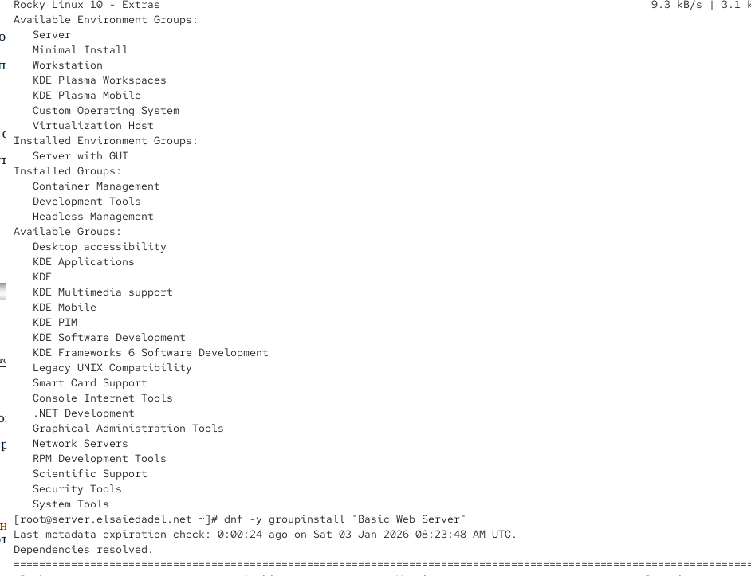

Установка группы пакетов Basic Web Server

## Настройка межсетевого экрана и запуск сервиса

В firewalld разрешён сервис `http`, после чего выполнено включение автозапуска и запуск службы Apache. Проверка статуса показала корректную работу сервиса.

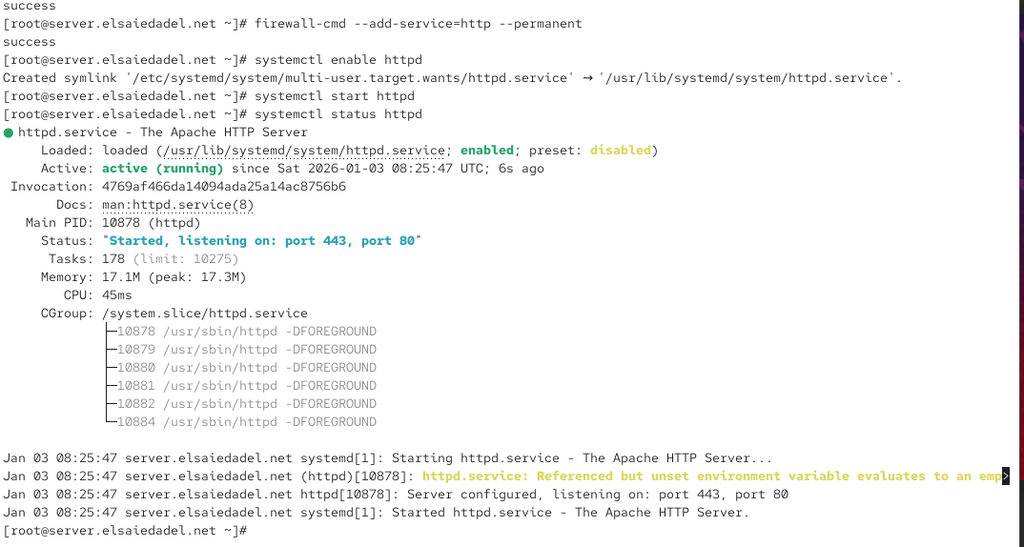

Запуск службы httpd и настройка firewall

## Доступ к серверу с client

Запущена виртуальная машина **client**. В браузере выполнен переход по IP-адресу сервера `192.168.1.1`. Отображение стандартной тестовой страницы Apache подтвердило корректную работу веб-сервера.

[figure not shown]

HTTP Server Test Page

## Анализ журналов Apache

На сервере выполнен мониторинг: - журнала ошибок `error_log`; - журнала доступа `access_log`.

Зафиксированы HTTP-запросы клиента, что подтверждает корректную обработку обращений веб-сервером.

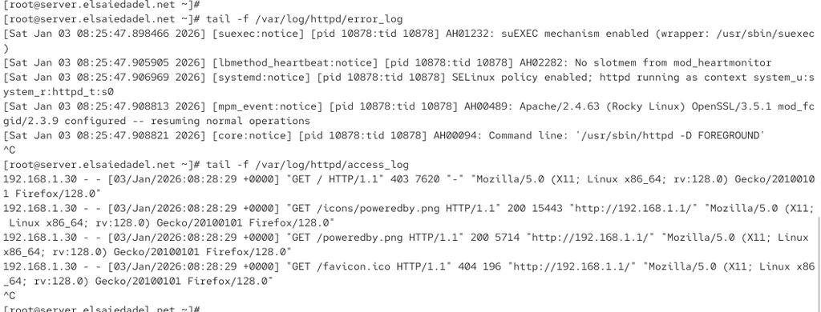

Мониторинг логов Apache

## Изменение DNS-зон

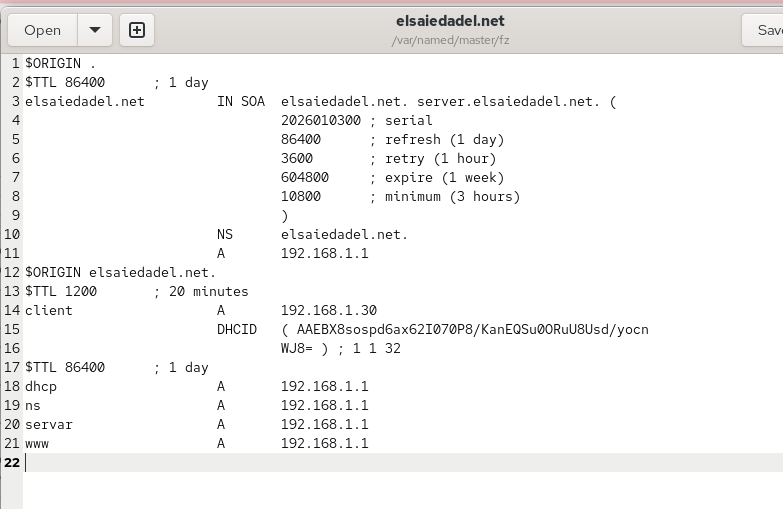

Прямая DNS-зона

## Изменение DNS-зон

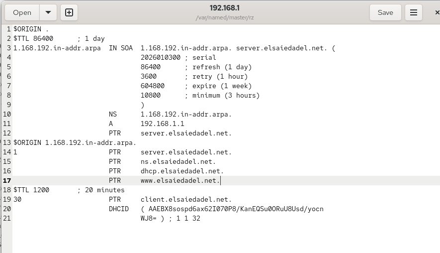

Обратная DNS-зона

## Конфигурация виртуальных хостов Apache

В каталоге `/etc/httpd/conf.d` созданы конфигурационные файлы виртуальных хостов для `server.elsaiedadel.net` и `www.elsaiedadel.net` с раздельными каталогами контента и логами.

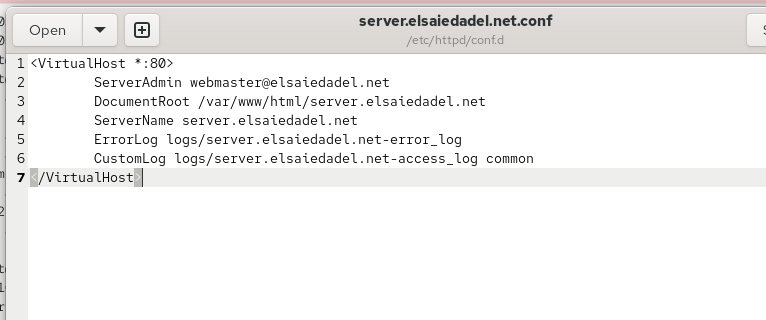

VirtualHost server.elsaiedadel.net

## Конфигурация виртуальных хостов Apache

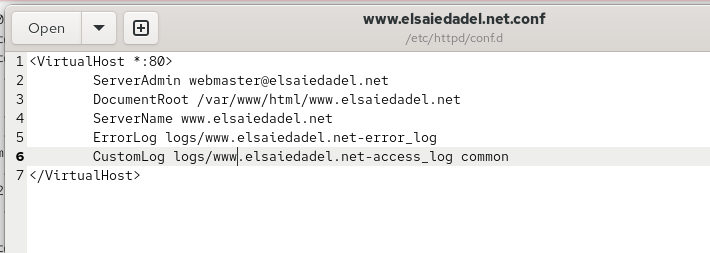

VirtualHost www.elsaiedadel.net

## Создание веб-контента

В каталоге `/var/www/html` созданы отдельные директории для каждого виртуального хоста. В файлах `index.html` размещены тестовые сообщения для идентификации серверов.

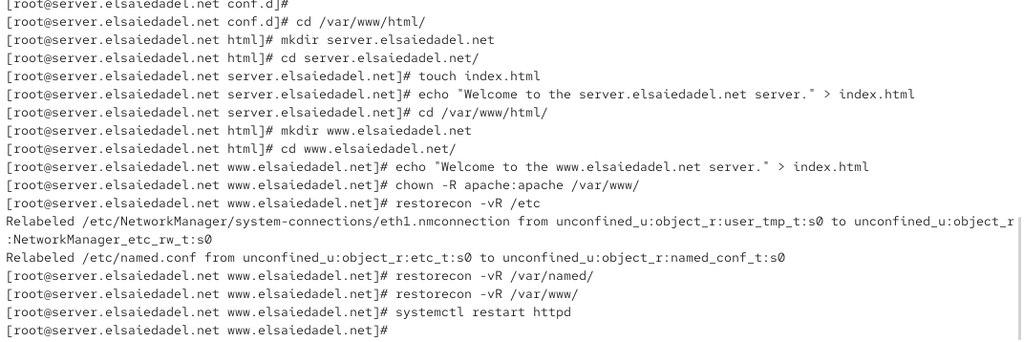

Создание тестовых страниц

## Проверка виртуального хостинга

С виртуальной машины **client** выполнена проверка доступа по DNS-именам `server.elsaiedadel.net` и `www.elsaiedadel.net`. Оба виртуальных хоста корректно отображают соответствующие страницы.

[figure not shown]

Доступ к server.elsaiedadel.net

## Проверка виртуального хостинга

[figure not shown]

Доступ к www.elsaiedadel.net

## Подготовка provisioning-окружения

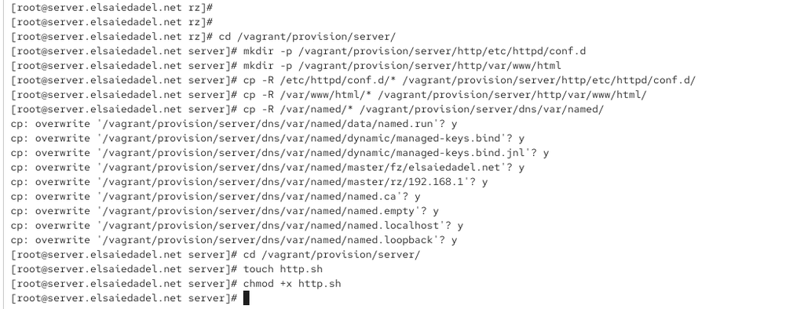

Provisioning-каталоги

## Скрипт автоматической настройки http.sh

Создан исполняемый скрипт `http.sh`, выполняющий установку Apache, копирование конфигураций, настройку SELinux, firewall и запуск сервиса httpd.

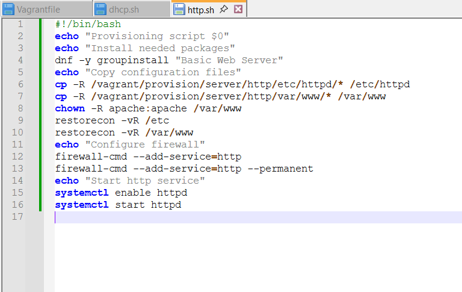

Скрипт http.sh

# Выводы

## Вывод

В ходе лабораторной работы был установлен и настроен HTTP-сервер Apache в среде Rocky Linux. Реализована настройка межсетевого экрана, анализ логов, виртуальный хостинг с использованием DNS и автоматизация конфигурации средствами provisioning. Полученные результаты подтверждают корректную работу веб-сервера и возможность масштабируемой и воспроизводимой настройки серверного окружения.